# UE BIME - TP SIG sous R

Boris Leroy, UMR BOREA, Muséum National d’Histoire Naturelle

# Etape 2 : Lecture des données sous R

## 2.1 Données vectorielles : polygones de distribution d’espèces

### 2.1.1 Avec le package terra

```r
library(terra)
iucn_t <- vect("./data/CAUDATA.shp")

# Résumé de l'objet
iucn_t
```

```
##  class       : SpatVector
##  geometry    : polygons
##  dimensions  : 910, 28  (geometries, attributes)
##  extent      : -144.9431, 177.1834, -37.53257, 71.24309  (xmin, xmax, ymin, ymax)
##  source      : CAUDATA.shp
##  coord. ref. : lon/lat WGS 84 (EPSG:4326)
##  names       : id_no        sci_name presence origin seasonal        compiler
##  type        : <int>           <chr>    <int>  <int>    <int>           <chr>
##  values      :  1093 Ambystoma lerm~        1      1        1 IUCN, Paulina ~
##                 1095 Ambystoma mexi~        1      1        1     Lauren Warr
##                 1098 Ambystoma cali~        1      1        1     Lauren Warr
##  yrcompiled        citation subspecies subpop (and 18 more)
##       <int>           <chr>      <chr>  <chr>
##        2014 IUCN (Internat~         NA     NA
##        2019 IUCN (Internat~         NA     NA
##        2020 IUCN (Internat~         NA     NA
```

Questions :

- Quel est le système de coordonnées ?

**WGS 84 (EPSG 4326)**

- Combien y a-t-il de polygones ?

**910**

- Combien y a-t-il de colonnes dans le tableau qui décrit les polygones ?

**28**

- Combien y a-t-il d’espèces ?

```r
# Certains noms d'espèces sont présents plusieurs fois :
iucn_t$sci_name[1:25] # Affichons uniquement les 25 premiers éléments
```

```
##  [1] "Ambystoma lermaense"        "Ambystoma mexicanum"
##  [3] "Ambystoma californiense"    "Ambystoma cingulatum"
##  [5] "Ambystoma cingulatum"       "Ambystoma cingulatum"
##  [7] "Andrias davidianus"         "Andrias japonicus"
##  [9] "Batrachoseps simatus"       "Batrachoseps stebbinsi"
## [11] "Batrachoseps campi"         "Batrachoseps relictus"
## [13] "Afghanodon mustersi"        "Paradactylodon persicus"
## [15] "Paradactylodon gorganensis" "Chioglossa lusitanica"
## [17] "Chioglossa lusitanica"      "Euproctus platycephalus"
## [19] "Eurycea nana"               "Eurycea sosorum"
## [21] "Eurycea tridentifera"       "Hydromantes brunus"
## [23] "Hynobius abei"              "Hynobius hidamontanus"
## [25] "Hynobius okiensis"
```

```r
# On regarde donc le nombre d'éléments uniques :
length(unique(iucn_t$sci_name))
```

```
## [1] 708
```

**Il y a 708 espèces.**

- Quelle est la famille la plus diversifiée d’urodèles ?

```r
plyr::count(iucn_t$family)
```

| x | freq |
| --- | --- |
| AMBYSTOMATIDAE | 47 |
| AMPHIUMIDAE | 3 |
| CRYPTOBRANCHIDAE | 4 |
| HYNOBIIDAE | 84 |
| PLETHODONTIDAE | 585 |
| PROTEIDAE | 11 |
| RHYACOTRITONIDAE | 4 |
| SALAMANDRIDAE | 166 |
| SIRENIDAE | 6 |

**Les plethodontidae.**

- Où se trouvent les espèces d’amphibiens urodèles ?

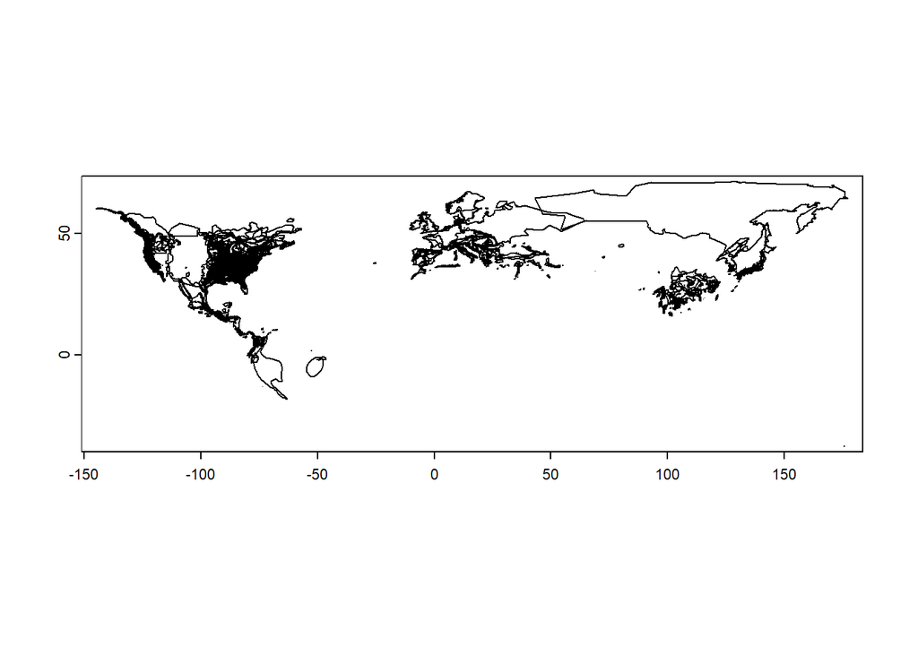

```r
plot(iucn_t)
```

### 2.1.2 Avec le package sf

```r
library(sf)
iucn_sf <- st_read("./data/CAUDATA.shp")
iucn_sf
```

| id_no | sci_name | presence | origin | seasonal | compiler | yrcompiled | citation | subspecies | subpop | source | island | tax_comm | dist_comm | generalisd | legend | kingdom | phylum | class | order_ | family | genus | category | marine | terrestial | freshwater | SHAPE_Leng | SHAPE_Area | geometry |
| --- | --- | --- | --- | --- | --- | --- | --- | --- | --- | --- | --- | --- | --- | --- | --- | --- | --- | --- | --- | --- | --- | --- | --- | --- | --- | --- | --- | --- |
| 1093 | Ambystoma lermaense | 1 | 1 | 1 | IUCN, Paulina Arias Caballero-CONABIO | 2014 | IUCN (International Union for Conservation of Nature), Conservation International & NatureServe, CONABIO (Comisión Nacional para el Conocimiento y Uso de la Biodiversidad) | NA | NA | NA | NA | NA | NA | 0 | Extant (resident) | ANIMALIA | CHORDATA | AMPHIBIA | CAUDATA | AMBYSTOMATIDAE | Ambystoma | EN | false | true | true | 0.68614087 | 2.567396e-02 |  |
| 1095 | Ambystoma mexicanum | 1 | 1 | 1 | Lauren Warr | 2019 | IUCN (International Union for Conservation of Nature), Conservation International & NatureServe | NA | NA | NA | NA | NA | NA | 0 | Extant (resident) | ANIMALIA | CHORDATA | AMPHIBIA | CAUDATA | AMBYSTOMATIDAE | Ambystoma | CR | false | false | true | 0.32291007 | 2.766332e-03 |  |
| 1098 | Ambystoma californiense | 1 | 1 | 1 | Lauren Warr | 2020 | IUCN (International Union for Conservation of Nature), Conservation International & NatureServe. | NA | NA | U.S. Geological Survey - Gap Analysis Project, 2017, California Tiger Salamander (Ambystoma californiense) aCTGSx_CONUS_2001v1 Range Map, http://doi.org/10.5066/F72N51DG. | NA | NA | NA | 0 | Extant (resident) | ANIMALIA | CHORDATA | AMPHIBIA | CAUDATA | AMBYSTOMATIDAE | Ambystoma | VU | false | true | true | 52.28329405 | 3.943718e+00 |  |
| 1099 | Ambystoma cingulatum | 4 | 1 | 1 | Lauren Warr | 2021 | IUCN (International Union for Conservation of Nature), Conservation International & NatureServe. | NA | NA | Semlitsch et al. 2017 | NA | NA | NA | 0 | Possibly Extinct | ANIMALIA | CHORDATA | AMPHIBIA | CAUDATA | AMBYSTOMATIDAE | Ambystoma | EN | false | true | true | 42.54392059 | 3.947943e+00 |  |
| 1099 | Ambystoma cingulatum | 1 | 1 | 1 | Lauren Warr | 2021 | IUCN (International Union for Conservation of Nature), Conservation International & NatureServe. | NA | NA | Semlitsch et al. 2017 & USFWS 2020 | NA | NA | NA | 0 | Extant (resident) | ANIMALIA | CHORDATA | AMPHIBIA | CAUDATA | AMBYSTOMATIDAE | Ambystoma | EN | false | true | true | 9.70240176 | 8.001380e-01 |  |
| 1099 | Ambystoma cingulatum | 3 | 1 | 1 | Lauren Warr | 2021 | IUCN (International Union for Conservation of Nature), Conservation International & NatureServe. | NA | NA | Semlitsch et al. 2017 | NA | NA | NA | 0 | Possibly Extant (resident) | ANIMALIA | CHORDATA | AMPHIBIA | CAUDATA | AMBYSTOMATIDAE | Ambystoma | EN | false | true | true | 31.45506405 | 3.717959e+00 |  |
| 1272 | Andrias davidianus | 1 | 1 | 1 | IUCN | 2008 | IUCN (International Union for Conservation of Nature), Conservation International & NatureServe. | NA | NA | NA | NA | NA | NA | 0 | Extant (resident) | ANIMALIA | CHORDATA | AMPHIBIA | CAUDATA | CRYPTOBRANCHIDAE | Andrias | CR | false | false | true | 84.41720279 | 4.562245e+01 |  |
| 1273 | Andrias japonicus | 1 | 1 | 1 | IUCN | 2021 | IUCN (International Union for Conservation of Nature) | NA | NA | NA | NA | NA | NA | 0 | Extant (resident) | ANIMALIA | CHORDATA | AMPHIBIA | CAUDATA | CRYPTOBRANCHIDAE | Andrias | VU | false | false | true | 27.01666152 | 5.623422e+00 |  |
| 2647 | Batrachoseps simatus | 1 | 1 | 1 | IUCN | 2008 | IUCN (International Union for Conservation of Nature), Conservation International & NatureServe. | NA | NA | Amphibiaweb, 2004 | NA | NA | NA | 0 | Extant (resident) | ANIMALIA | CHORDATA | AMPHIBIA | CAUDATA | PLETHODONTIDAE | Batrachoseps | VU | false | true | false | 0.66893018 | 1.780573e-02 |  |
| 2648 | Batrachoseps stebbinsi | 1 | 1 | 1 | IUCN | 2008 | IUCN (International Union for Conservation of Nature), Conservation International & NatureServe. | NA | NA | Amphibiaweb, 2004 | NA | NA | NA | 0 | Extant (resident) | ANIMALIA | CHORDATA | AMPHIBIA | CAUDATA | PLETHODONTIDAE | Batrachoseps | VU | false | true | false | 1.13642358 | 3.490326e-02 |  |

[output cut: 900 more lines]

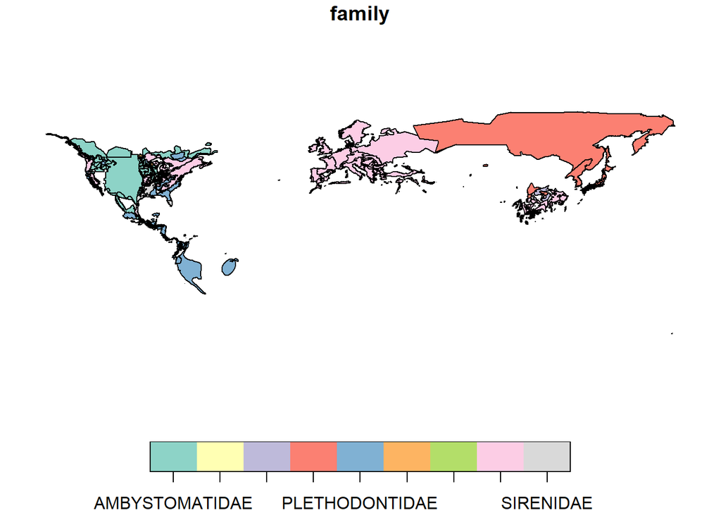

```r
plot(iucn_sf["family"])
```

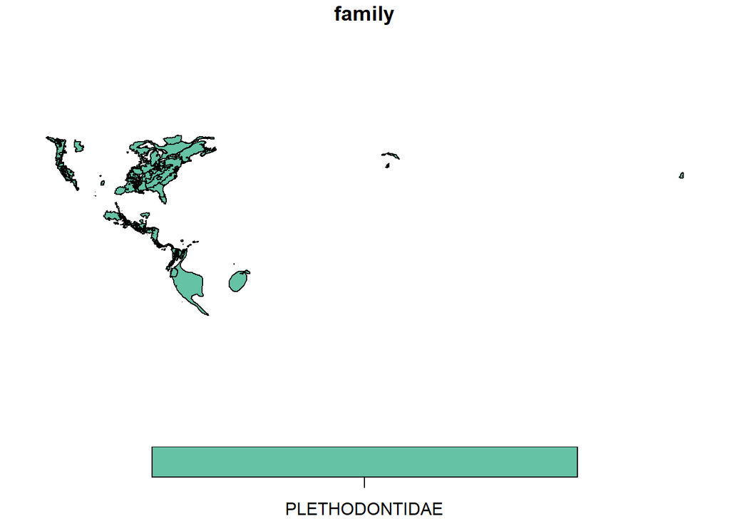

```r
plot(iucn_sf[which(iucn_sf$family == "PLETHODONTIDAE"),
             "family"])
```

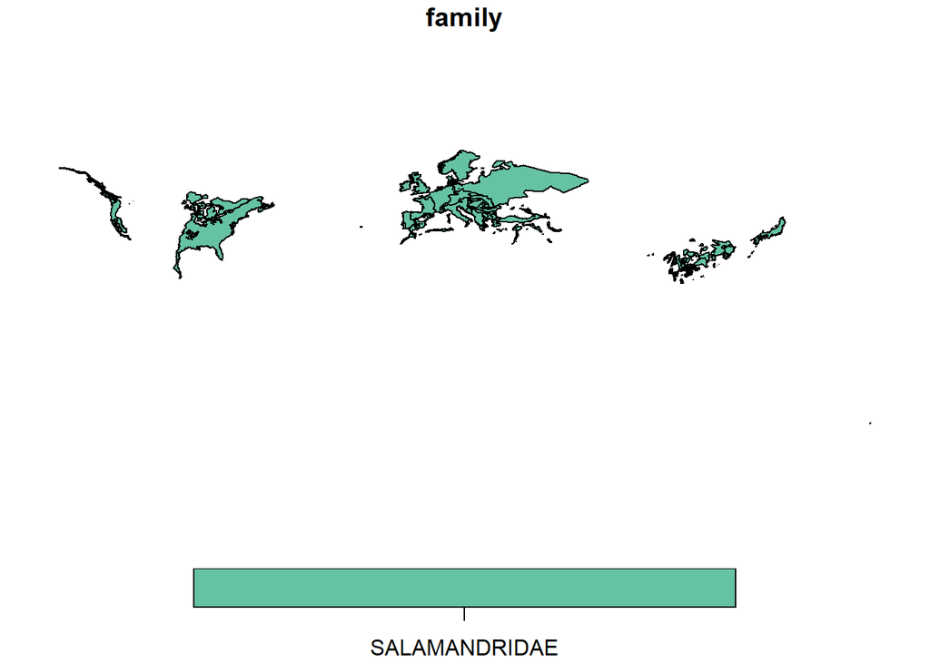

```r
plot(iucn_sf[which(iucn_sf$family == "SALAMANDRIDAE"),
             "family"])
```

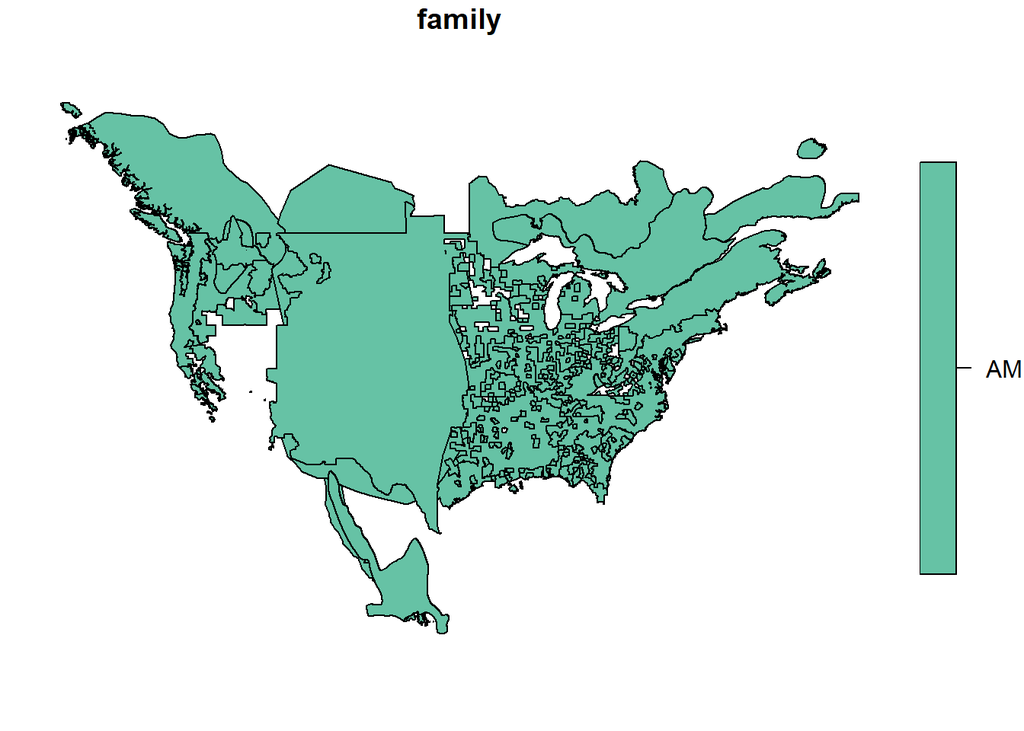

```r
plot(iucn_sf[which(iucn_sf$family == "AMBYSTOMATIDAE"),
             "family"])
```

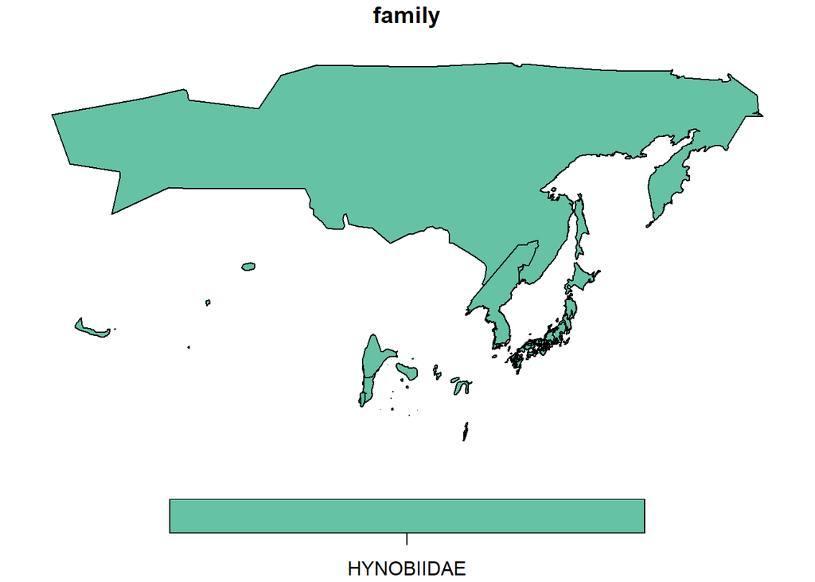

```r
plot(iucn_sf[which(iucn_sf$family == "HYNOBIIDAE"),
             "family"])
```

- Comment sont réparties géographiquement les familles majoritaires d’urodèles ?

### 2.2 Données vectorielles : limites des continents

```r
continents <- st_read("./data/ne_50m_coastline.shp")
```

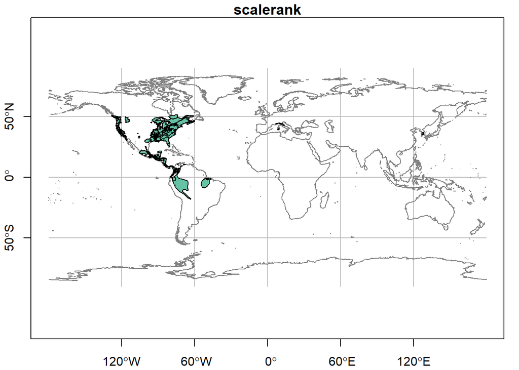

```r
plot(continents[1], col = grey(.5),
     reset = FALSE, graticule = TRUE, axes = TRUE)

plot(iucn_sf[which(iucn_sf$family == "PLETHODONTIDAE"),
             "family"], add = TRUE)
```

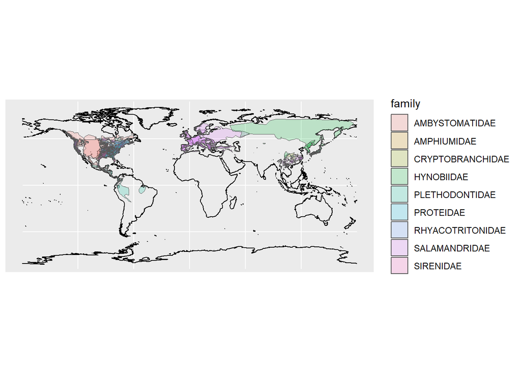

```r
library(ggplot2)
ggplot() +
  geom_sf(data = continents) +
  geom_sf(data = iucn_sf, aes(fill = family),
          alpha = .2)
```

### 2.3 Données raster : climatologies WorldClim

```r
jan <- rast("./data/WorldClim data/wc2.1_10m_tavg_01.tif")
jan
```

```
## class       : SpatRaster
## dimensions  : 1080, 2160, 1  (nrow, ncol, nlyr)
## resolution  : 0.1666667, 0.1666667  (x, y)
## extent      : -180, 180, -90, 90  (xmin, xmax, ymin, ymax)
## coord. ref. : lon/lat WGS 84 (EPSG:4326)
## source      : wc2.1_10m_tavg_01.tif
## name        : wc2.1_10m_tavg_01
## min value   :          -45.8840
## max value   :           34.0095
```

- Quelle est la résolution du raster ?

**0.167°**

- Quel est le système de coordonnées ?

**WGS 84**

- Quelle sont les températures moyennes de janvier les plus élevées et les plus froides sur la Terre, et où sont-elles situées ?

```r
jan
```

```
## class       : SpatRaster
## dimensions  : 1080, 2160, 1  (nrow, ncol, nlyr)
## resolution  : 0.1666667, 0.1666667  (x, y)
## extent      : -180, 180, -90, 90  (xmin, xmax, ymin, ymax)
## coord. ref. : lon/lat WGS 84 (EPSG:4326)
## source      : wc2.1_10m_tavg_01.tif
## name        : wc2.1_10m_tavg_01
## min value   :          -45.8840
## max value   :           34.0095
```

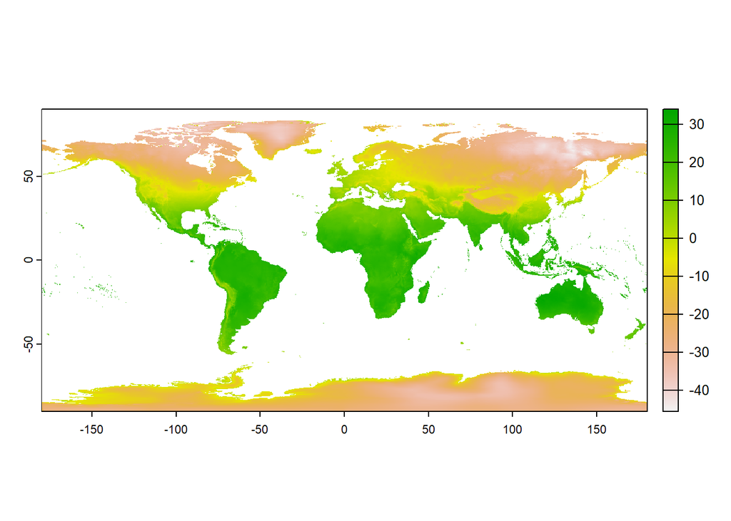

```r
plot(jan)
```

**-45°C et 34°C sont les moyennes mensuelles les plus froides et élevées respectivement. Elles sont localisées en Sibérie pour la première, et dans les zones tropicales pour la seconde.**

Question :

- Calculez et affichez la moyenne annuelle des températures.

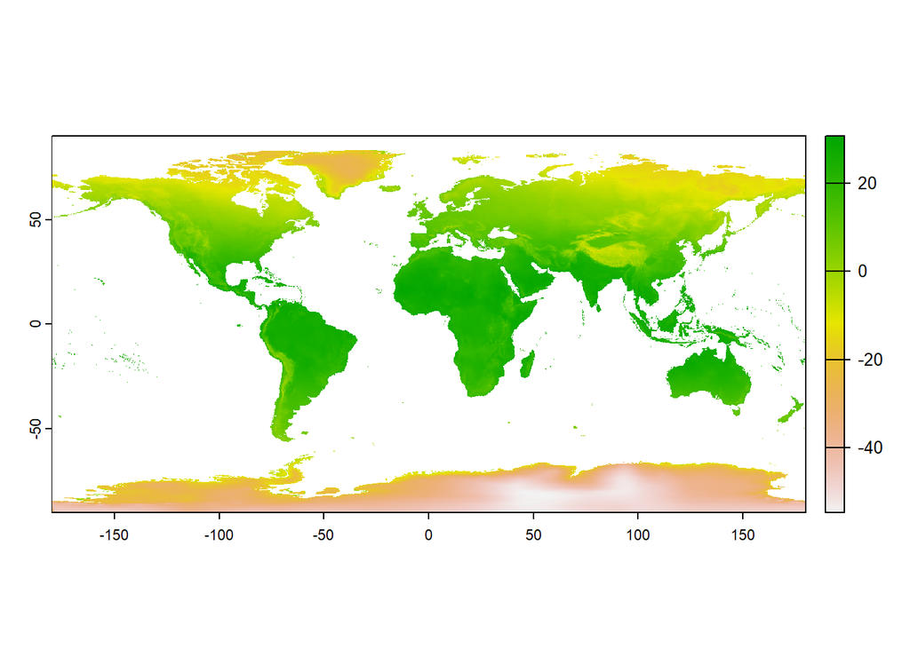

```r
worldclim <- rast(paste0("./data/WorldClim data/", list.files("./data/WorldClim data/")))
MAT <- mean(worldclim, na.rm = T)
plot(MAT)
```

# Etape 3 : analyse biogéographique de la diversité d’urodèles

## 3.1 Distributions d’urodèles natives et non éteintes

```r
iucn_sf <- iucn_sf[which(iucn_sf$presence == 1), ]
iucn_sf <- iucn_sf[which(iucn_sf$origin == 1), ]
# = la même chose que :
iucn_sf <- iucn_sf[which(iucn_sf$presence == 1 & iucn_sf$origin == 1), ]

# Certains polygones sont dupliqués : pour la même espèce, on peut avoir plusieurs polygones
iucn_sf[which(duplicated(iucn_sf$sci_name)), ]
```

|  | id_no | sci_name | presence | origin | seasonal | compiler | yrcompiled | citation | subspecies | subpop | source | island | tax_comm | dist_comm | generalisd | legend | kingdom | phylum | class | order_ | family | genus | category | marine | terrestial | freshwater | SHAPE_Leng | SHAPE_Area | geometry |
| --- | --- | --- | --- | --- | --- | --- | --- | --- | --- | --- | --- | --- | --- | --- | --- | --- | --- | --- | --- | --- | --- | --- | --- | --- | --- | --- | --- | --- | --- |
| 62 | 29426 | Nototriton brodiei | 1 | 1 | 1 | Louise Hobin | 2019 | IUCN (International Union for Conservation of Nature), Conservation International & NatureServe | NA | NA | NA | NA | NA | NA | 0 | Extant (resident) | ANIMALIA | CHORDATA | AMPHIBIA | CAUDATA | PLETHODONTIDAE | Nototriton | EN | false | true | false | 0.43644581 | 5.146664e-03 |  |
| 70 | 54360 | Cryptotriton monzoni | 1 | 1 | 1 | Lauren Warr and Kelsey Neam | 2019 | IUCN (International Union for Conservation of Nature), Conservation International & NatureServe. | NA | NA | NA | NA | NA | NA | 0 | Extant (resident) | ANIMALIA | CHORDATA | AMPHIBIA | CAUDATA | PLETHODONTIDAE | Cryptotriton | CR | false | true | false | 0.11056381 | 4.693136e-04 |  |
| 81 | 59059 | Ambystoma jeffersonianum | 1 | 1 | 1 | IUCN | 2021 | IUCN (International Union for Conservation of Nature), Conservation International & NatureServe. | NA | NA | Blackburn et al., 2001 | NA | NA | NA | 0 | Extant (resident) | ANIMALIA | CHORDATA | AMPHIBIA | CAUDATA | AMBYSTOMATIDAE | Ambystoma | LC | false | true | true | 128.17064500 | 4.999141e+01 |  |
| 83 | 59060 | Ambystoma laterale | 1 | 1 | 1 | IUCN | 2020 | IUCN (International Union for Conservation of Nature), Conservation International & NatureServe. | NA | NA | Blackburn et al., 2001; Conant and Collins, 1998 | NA | NA | NA | 0 | Extant (resident) | ANIMALIA | CHORDATA | AMPHIBIA | CAUDATA | AMBYSTOMATIDAE | Ambystoma | LC | false | true | true | 222.75151537 | 1.762141e+02 |  |
| 84 | 59060 | Ambystoma laterale | 1 | 1 | 1 | IUCN | 2020 | IUCN (International Union for Conservation of Nature), Conservation International & NatureServe. | NA | NA | Blackburn et al., 2001 | NA | NA | NA | 0 | Extant (resident) | ANIMALIA | CHORDATA | AMPHIBIA | CAUDATA | AMBYSTOMATIDAE | Ambystoma | LC | false | true | true | 91.41712085 | 2.862717e+01 |  |
| 89 | 59064 | Ambystoma maculatum | 1 | 1 | 1 | IUCN | 2020 | IUCN (International Union for Conservation of Nature), Conservation International & NatureServe. | NA | NA | Blackburn et al. 2001, Conant and Collins 1998 | NA | NA | NA | 0 | Extant (resident) | ANIMALIA | CHORDATA | AMPHIBIA | CAUDATA | AMBYSTOMATIDAE | Ambystoma | LC | false | true | true | 468.14129092 | 2.475346e+02 |  |
| 90 | 59064 | Ambystoma maculatum | 1 | 1 | 1 | IUCN | 2020 | IUCN (International Union for Conservation of Nature), Conservation International & NatureServe. | NA | NA | NA | NA | NA | NA | 0 | Extant (resident) | ANIMALIA | CHORDATA | AMPHIBIA | CAUDATA | AMBYSTOMATIDAE | Ambystoma | LC | false | true | true | 0.12651166 | 5.116800e-04 |  |
| 98 | 59071 | Ambystoma texanum | 1 | 1 | 1 | IUCN | 2021 | IUCN (International Union for Conservation of Nature), Conservation International & NatureServe. | NA | NA | Species at Risk Branch, 2002 | NA | NA | NA | 0 | Extant (resident) | ANIMALIA | CHORDATA | AMPHIBIA | CAUDATA | AMBYSTOMATIDAE | Ambystoma | LC | false | true | true | 0.33280947 | 4.791671e-03 |  |
| 118 | 59099 | Hynobius nigrescens | 1 | 1 | 1 | IUCN | 2020 | IUCN (International Union for Conservation of Nature). | NA | NA | NA | NA | NA | NA | 0 | Extant (resident) | ANIMALIA | CHORDATA | AMPHIBIA | CAUDATA | HYNOBIIDAE | Hynobius | LC | false | true | true | 23.44521583 | 8.431849e+00 |  |
| 125 | 59106 | Hynobius yiwuensis | 1 | 1 | 1 | jie Wang & Louise Hobin | 2019 | IUCN (International Union for Conservation of Nature) & Conservation International | NA | NA | NA | NA | NA | NA | 0 | Extant (resident) | ANIMALIA | CHORDATA | AMPHIBIA | CAUDATA | HYNOBIIDAE | Hynobius | LC | false | true | true | 11.04989009 | 2.339111e+00 |  |

[output cut: 101 more lines]

## 3.2 Travail sur une résolution plus grossière pour réduire le temps de calcul

```r
# On utilisera comme base de calcul le
# raster de température moyenne annuelle agrégé par facteur 6
MAT <- aggregate(MAT,
                 fact = 6)
```

## 3.3 Calcul de la richesse spécifique

```r
# 0. Etape préalable souvent nécessaire
# S'assurer que les polygones sont valides. Souvent, ils ne le sont
# pas, ce qui cause des erreurs de calcul ; pour éviter les problèmes,
# on utilise st_make_valid() :
iucn_sf <- st_make_valid(iucn_sf)

# 1. Regrouper les polygones par espèce. Cette opération est longue
# Soyez patients ! Cela prend plusieurs minutes.
# Si c'est trop long vous pouvez faire le calcul sur une famille seulement

# Utilisons la syntaxe du package dplyr pour écrire ce code de manière simple :
library(dplyr)
```

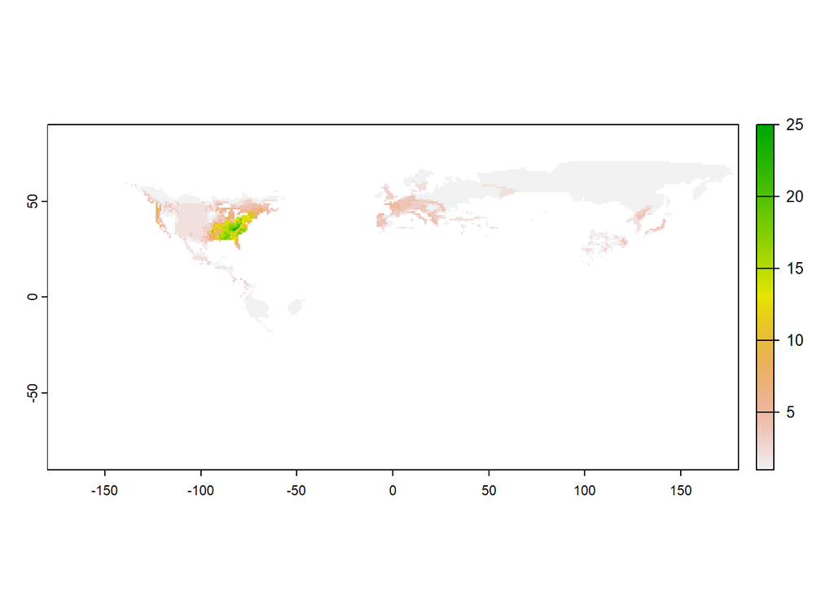

```r
iucn_poly_par_sp <- iucn_sf %>%
  group_by(sci_name) %>%
  summarise(geometry = st_union(geometry))
# Lisons ce code :
# Partir du tableau iucn_sf
# Le grouper par rapport à la colonne sci_name (= grouper par espèce)
# Réaliser l'union des polygones (st_union(geometry)) et obtenir comme
# résultat un tableau avec une seule ligne par espèce (summarise())

# 2. Ajouter une colonne numérique avec la valeur '1' pour chaque
# espèce. Cette astuce nous permettra de calculer la somme dans chaque
# cellule ensuite
iucn_poly_par_sp$occurrence <- 1


# 3. Calculer la richesse
# On utilise la commande 'rasterize' qui transforme les polygones
# en rasters. Pour chaque cellule, on va demander à la fonction
# de calculer la somme de la colonne 'occurrence', ce qui reviendra
# à compter le nombre d'espèces qui ont un polygone chevauchant la
# cellule.
# On utilise notre raster de température comme modèle de base ici (MAT)
richness <- rasterize(iucn_poly_par_sp,
                      MAT,
                      field = "occurrence",
                      fun = sum)

plot(richness)
```

Questions :

- Où est la richesse la plus élevée ?

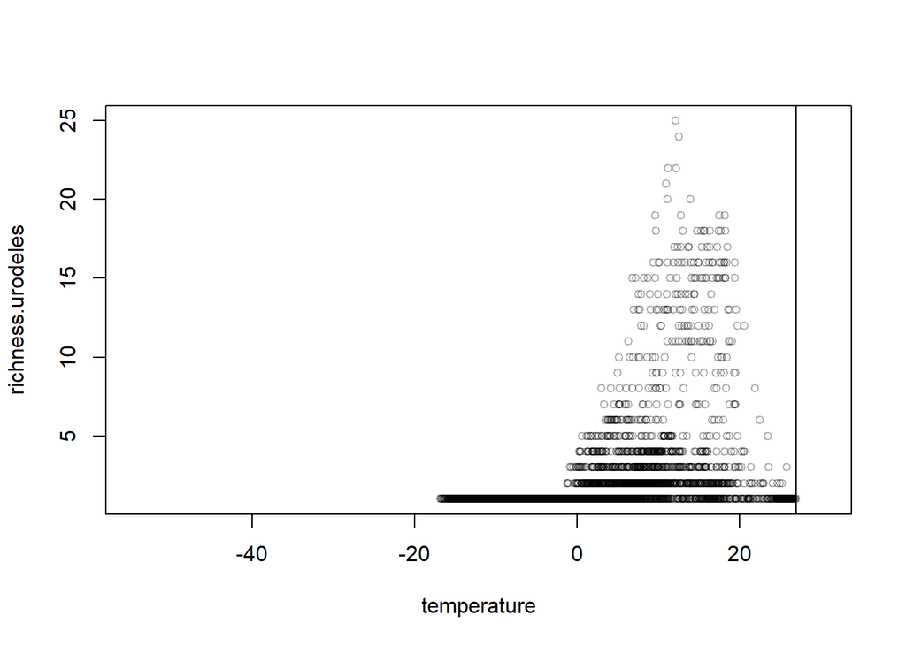

```r
richness.urodeles <- values(richness)
temperature <- values(MAT)

plot(richness.urodeles ~ temperature,
     cex = .8, pch = 1, col = rgb(0,0,0,alpha=0.3))
abline(v = 27)
```

- Que pouvez-vous déduire sur les limites de température des urodèles ?

- Que remarquez-vous de particulier sur le graphe température/richesse ?

**Il y a une seule espèce qui peut supporter des températures moyennes annuelles allant jusqu’à - 18°C. Il s’agit de Salamandrella keyserlingii, une salamandre de Sibérie qui peut hiberner dans des conditions de température extrêmes.**

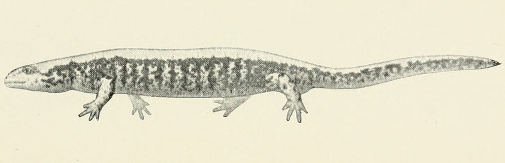

# Etape 4 : faire une belle carte

```r
e <- ext(-180, 180, 0, 90)
richness <- crop(richness,
                 e)

# Projection suivant Lambert Azimutal Equal Area
richness.laea <- project(richness,
                         "+proj=laea +lat_0=90 +lon_0=0",
                         method = "bilinear")
# Appliquons la même projection sur le vecteur des limites des continents :
continents.laea <- st_transform(continents, crs = "+proj=laea +lat_0=90 +lon_0=0")

library(tmap)
```

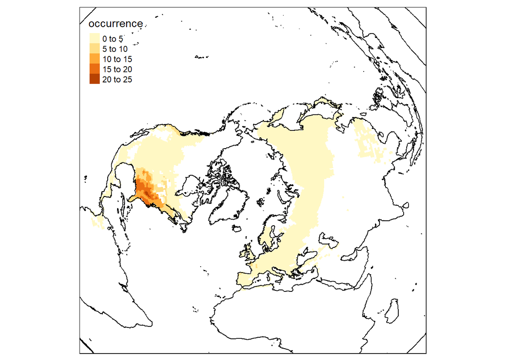

```r
richness.map <- tm_shape(richness.laea) +
                tm_raster()

continents.map <- tm_shape(continents.laea) +
                  tm_lines()


richness.map + continents.map
```